# Starter notebook

This notebook is provided for your team to get the work started. It has the paths to the source files, and two quick count queries.

## Cluster setup

You should use a cluster with the following parameters:

- Node size: _Standard_E4s_v3_
- Dynamically allocate executors: Disabled
- Executors: 6
- Executor size: Small (4 vCPUs, 28 GB memory)

```python
spark
```

```
StatementMeta(068f5dc9-cad0-404f-b813-890e0a09f2cd, 13, 8, Finished, Available)
```

**SparkSession - hive**

**SparkContext**

[Spark UI](http://vm-eb450068:38849)

**Version**

`v3.2.2.5.1-96380145`

**Master**

`yarn`

**AppName**

`Azure ML Experiment`

##### Analysis Goals

As individuals involved in data, we were curious about the activity of the r/datascience subreddit, and we thought of the following questions that would give us an idea on how the subreddit community saw certain topics.

- Which programming languages are most popular?
- How has ChatGPT interest increased over time?
- Who are the top contributors of the subreddit?

##### Loading and checking data

```python
comments_path = "wasbs://data@dnsc6290teacher.blob.core.windows.net/reddit/parquet/comments/"
submissions_path = "wasbs://data@dnsc6290teacher.blob.core.windows.net/reddit/parquet/submissions/"
```

```
StatementMeta(068f5dc9-cad0-404f-b813-890e0a09f2cd, 13, 9, Finished, Available)
```

```python
#Import functions

from pyspark.sql.functions import col, isnan, when, count, dayofweek, hour, to_timestamp, sum
```

```
StatementMeta(068f5dc9-cad0-404f-b813-890e0a09f2cd, 13, 10, Finished, Available)
```

```python
comments = spark.read.parquet(comments_path)
submissions = spark.read.parquet(submissions_path)
```

```
StatementMeta(068f5dc9-cad0-404f-b813-890e0a09f2cd, 13, 11, Finished, Available)
```

```python
comments.count()
```

```
StatementMeta(068f5dc9-cad0-404f-b813-890e0a09f2cd, 13, 12, Finished, Available)
```

```
701085826
```

```python
comments.printSchema()
```

```
StatementMeta(068f5dc9-cad0-404f-b813-890e0a09f2cd, 13, 13, Finished, Available)
```

```
root
 |-- author: string (nullable = true)
 |-- body: string (nullable = true)
 |-- controversiality: long (nullable = true)
 |-- created_utc: timestamp (nullable = true)
 |-- distinguished: string (nullable = true)
 |-- id: string (nullable = true)
 |-- is_submitter: boolean (nullable = true)
 |-- link_id: string (nullable = true)
 |-- parent_id: string (nullable = true)
 |-- retrieved_on: timestamp (nullable = true)
 |-- score: long (nullable = true)
 |-- stickied: boolean (nullable = true)
 |-- subreddit: string (nullable = true)
```

```python
comments.createOrReplaceTempView("comments_sql")
comment_counts_by_subreddit_by_month = spark.sql("""
    select subreddit, extract(month FROM created_utc) as month,
    count(*) as ct from comments_sql
    group by 1, 2
    """)
```

```
StatementMeta(068f5dc9-cad0-404f-b813-890e0a09f2cd, 13, 14, Finished, Available)
```

```python
comment_counts_by_subreddit_by_month.show()
```

```
StatementMeta(068f5dc9-cad0-404f-b813-890e0a09f2cd, 13, 15, Finished, Available)
```

```
+-------------------+-----+------+
|          subreddit|month|    ct|
+-------------------+-----+------+
|LateStageCapitalism|    2| 78692|
|             canada|    2|239500|
|          GayMexico|    2| 14458|
|             selfie|    2|126146|
|       cuteonlyfans|    2| 31235|
|             18nsfw|    2|  6547|
|               tifu|    2| 89410|
|   Genshin_Memepact|    2| 71919|
|         depression|    2| 24294|
|             loseit|    2| 55817|
|    FreeCompliments|    2| 95112|
|           buildapc|    2|146053|
|             Boxing|    2| 72407|
| CrazyFuckingVideos|    2|224410|
|    gaybrosgonemild|    2| 22673|
|            lovense|    2| 19025|
|     brandonherrara|    2| 17446|
|    SelfDrivingCars|    2|  2937|
|         sharpening|    2|  6493|
|             elgato|    2|  2873|
+-------------------+-----+------+
only showing top 20 rows
```

```python
submissions.count()
```

```
StatementMeta(068f5dc9-cad0-404f-b813-890e0a09f2cd, 13, 16, Finished, Available)
```

```
109744570
```

```python
submissions.printSchema()
```

```
StatementMeta(068f5dc9-cad0-404f-b813-890e0a09f2cd, 13, 17, Finished, Available)
```

```
root
 |-- id: string (nullable = true)
 |-- author: string (nullable = true)
 |-- created_utc: timestamp (nullable = true)
 |-- subreddit: string (nullable = true)
 |-- selftext: string (nullable = true)
 |-- title: string (nullable = true)
 |-- num_comments: long (nullable = true)
 |-- score: long (nullable = true)
 |-- is_self: boolean (nullable = true)
 |-- over_18: boolean (nullable = true)
 |-- crosspost_parent: string (nullable = true)
 |-- num_crossposts: long (nullable = true)
 |-- distinguished: string (nullable = true)
 |-- promoted: boolean (nullable = true)
 |-- stickied: boolean (nullable = true)
 |-- retrieved_on: timestamp (nullable = true)
```

```python
submissions.createOrReplaceTempView("submissions_sql")
submissions_counts_by_subreddit_by_month = spark.sql("""
    select subreddit, extract(month FROM created_utc) as month,
    count(*) as ct from submissions_sql
    group by 1, 2
    """)
```

```
StatementMeta(068f5dc9-cad0-404f-b813-890e0a09f2cd, 13, 18, Finished, Available)
```

```python
submissions_counts_by_subreddit_by_month.show()
```

```
StatementMeta(068f5dc9-cad0-404f-b813-890e0a09f2cd, 13, 19, Finished, Available)
```

```
+--------------------+-----+-----+
|           subreddit|month|   ct|
+--------------------+-----+-----+
|        tinydickfans|    2|   43|
|u_Witty_Definitio...|    2|   37|
|        cuteonlyfans|    2|19408|
|          depression|    2|10547|
|            buildapc|    2|19085|
|           KrunkerIO|    2|  304|
|             lovense|    2| 9736|
|           GayMexico|    2| 8993|
|              loseit|    2| 4327|
|        smgwarrelics|    2|   16|
|   sanctuaryofhentai|    2|  190|
|    Genshin_Memepact|    2| 3329|
|              selfie|    2|20327|
|              petite|    2| 6175|
|         americandad|    2| 1366|
|           DrSquatch|    2|  240|
|           NewTubers|    2| 3085|
|     FreeCompliments|    2| 9326|
|u_RelativeExpert2588|    2|    1|
|            Bullpups|    2|   92|
+--------------------+-----+-----+
only showing top 20 rows
```

```python
submissions.show()
```

```
StatementMeta(068f5dc9-cad0-404f-b813-890e0a09f2cd, 13, 20, Finished, Available)
```

```
+-------+--------------------+-------------------+-------------------+--------------------+--------------------+------------+-----+-------+-------+----------------+--------------+-------------+--------+--------+-------------------+
|     id|              author|        created_utc|          subreddit|            selftext|               title|num_comments|score|is_self|over_18|crosspost_parent|num_crossposts|distinguished|promoted|stickied|       retrieved_on|
+-------+--------------------+-------------------+-------------------+--------------------+--------------------+------------+-----+-------+-------+----------------+--------------+-------------+--------+--------+-------------------+
|117rlxk|           [deleted]|2023-02-21 02:11:04|        Needafriend|           [deleted]|M21 bored and loo...|           2|    2|   true|  false|            null|             0|         null|    null|   false|2023-03-09 00:02:07|
|117rlxl|           [deleted]|2023-02-21 02:11:04|     wallstreetbets|           [removed]|will panw go up t...|           2|    1|   true|  false|            null|             0|         null|    null|   false|2023-03-09 00:02:07|
|117rlxm|           shock1964|2023-02-21 02:11:04|skilledidiotsincars|                    |Motorcyclist coul...|           0|   23|  false|  false|      t3_1175vyb|             0|         null|    null|   false|2023-03-09 00:02:07|
|117rlxn|  Yo_Mama_So_FatHehe|2023-02-21 02:11:04|      EyeBlechAgain|I barely see any ...|  STOP THIS BULLSHIT|           7|   52|   true|   true|            null|             0|         null|    null|   false|2023-03-09 00:02:07|
|117rlxo|           [deleted]|2023-02-21 02:11:04|    BreastExpansion|           [removed]|Succubus full bod...|           0|    1|  false|   true|            null|             0|         null|    null|   false|2023-03-09 00:02:07|
|117rlxp|           [deleted]|2023-02-21 02:11:04|            cocaine|           [deleted]|25 m, who's chatt...|           1|    1|   true|  false|            null|             0|         null|    null|   false|2023-03-09 00:02:07|
|117rlxq|           [deleted]|2023-02-21 02:11:05|             pornID|           [removed]|Anyone know this ...|           0|    1|  false|   true|            null|             0|         null|    null|   false|2023-03-09 00:02:07|
|117rlxr|        dontetaylorx|2023-02-21 02:11:05|        hardcutdick|                    |   Hard &amp; Cut 😈|           0|   11|  false|   true|            null|             0|         null|    null|   false|2023-03-09 00:02:07|
|117rlxs|           zmmmmmzzz|2023-02-21 02:11:05|      FreeKarma4You|                    |          Need karma|           9|   11|   true|  false|            null|             0|         null|    null|   false|2023-03-09 00:02:07|
|117rlxt|       cutewaffle355|2023-02-21 02:11:05|          smallgirl|                    |Hey baby, what ar...|           0|    1|  false|   true|            null|             0|         null|    null|   false|2023-03-09 00:02:07|
|117rlxu|           [deleted]|2023-02-21 02:11:05|             Advice|           [removed]|Is my (30F) boyfr...|           1|    1|   true|   true|            null|             0|         null|    null|   false|2023-03-09 00:02:07|
|117rlxv|     No_Original3154|2023-02-21 02:11:05|          BabesNSFW|                    |Would you dump yo...|           1|    1|  false|   true|      t3_117ripf|             0|         null|    null|   false|2023-03-09 00:02:07|
|117rlxx|           [deleted]|2023-02-21 02:11:05|             B_Cups|           [deleted]|I feel that we ar...|           1|    3|  false|   true|            null|             0|         null|    null|   false|2023-03-09 00:02:07|
|117rlxy|           [deleted]|2023-02-21 02:11:05|      rapefantasies|           [deleted]|She asked me to p...|           0|    2|  false|   true|            null|             0|         null|    null|   false|2023-03-09 00:02:07|
|117rlxz|       cutewaffle355|2023-02-21 02:11:05| college_dorm_girls|                    |How is it baby, y...|           0|    6|  false|   true|            null|             0|         null|    null|   false|2023-03-09 00:02:07|
|117rly0|    ThatRemoteWriter|2023-02-21 02:11:05|           CelebDPP|Having the perfec...|[M4F] (OC) Actor ...|           0|    1|   true|   true|            null|             0|         null|    null|   false|2023-03-09 00:02:07|
|117rly1|       Any-Control76|2023-02-21 02:11:05|         malaysians|All girls here pl...|Why do guys fail ...|          29|    7|   true|  false|            null|             0|         null|    null|   false|2023-03-09 00:02:07|
|117rly2|   PenaltySuperb4900|2023-02-21 02:11:05|    whatisthisthing|                    |Peter Millar Butt...|           2|    1|  false|  false|            null|             0|         null|    null|   false|2023-03-09 00:02:07|
|117rly3|Spiritual-Minimum-55|2023-02-21 02:11:05|   AfricanWomenNSFW|                    |Don’t be shy, com...|           0|    0|  false|   true|            null|             0|         null|    null|   false|2023-03-09 00:02:07|
|117rly5|            EchoJobs|2023-02-21 02:11:05|        ReactJSJobs|                    |Via is hiring Sen...|           0|    1|  false|  false|            null|             0|         null|    null|   false|2023-03-09 00:02:07|
+-------+--------------------+-------------------+-------------------+--------------------+--------------------+------------+-----+-------+-------+----------------+--------------+-------------+--------+--------+-------------------+
only showing top 20 rows
```

```python
# Submissions in "datascience" subreddit

submissions_ds = submissions.filter(submissions.subreddit == "datascience")

submissions_ds.count()
```

```
StatementMeta(068f5dc9-cad0-404f-b813-890e0a09f2cd, 13, 21, Finished, Available)
```

```
5117
```

```python
# Removing null values in submissions_ds

submissions_ds = submissions_ds.dropna(subset=["author", "created_utc", "subreddit", "title"])

submissions_ds.count()
```

```
StatementMeta(068f5dc9-cad0-404f-b813-890e0a09f2cd, 13, 22, Finished, Available)
```

```
5117
```

```python
# Comments in "datascience" subreddit

comments_ds = comments.filter(comments.subreddit == "datascience")

comments_ds.count()
```

```
StatementMeta(068f5dc9-cad0-404f-b813-890e0a09f2cd, 13, 23, Finished, Available)
```

```
54685
```

```python
# Removing null values in comments_ds

comments_ds = comments_ds.dropna(subset=["author", "created_utc", "subreddit", "body"])

comments_ds.count()
```

```
StatementMeta(068f5dc9-cad0-404f-b813-890e0a09f2cd, 13, 24, Finished, Available)
```

```
54685
```

```python
submissions_ds.show(5)
```

```
StatementMeta(068f5dc9-cad0-404f-b813-890e0a09f2cd, 13, 25, Finished, Available)
```

```
+-------+---------+-------------------+-----------+--------------------+--------------------+------------+-----+-------+-------+----------------+--------------+-------------+--------+--------+-------------------+
|     id|   author|        created_utc|  subreddit|            selftext|               title|num_comments|score|is_self|over_18|crosspost_parent|num_crossposts|distinguished|promoted|stickied|       retrieved_on|
+-------+---------+-------------------+-----------+--------------------+--------------------+------------+-----+-------+-------+----------------+--------------+-------------+--------+--------+-------------------+
|117si3k|Davidvm97|2023-02-21 02:54:37|datascience|So, basically the...|Software Engineer...|           1|    0|   true|  false|            null|             0|         null|    null|   false|2023-03-09 00:01:29|
|117u5x1| qorkLand|2023-02-21 04:17:44|datascience|Hello everyone, i...|Request for a ref...|           1|    0|   true|  false|            null|             1|         null|    null|   false|2023-03-09 00:00:19|
|117weng| Errageek|2023-02-21 06:19:13|datascience|                    |CLEAR VIDEO EXPLA...|           0|    1|  false|  false|            null|             0|         null|    null|   false|2023-03-08 23:58:43|
|117wh0x|[deleted]|2023-02-21 06:23:03|datascience|           [deleted]|ba in economics w...|           2|    0|   true|  false|            null|             0|         null|    null|   false|2023-03-08 23:58:41|
|117wm5e|[deleted]|2023-02-21 06:31:22|datascience|           [deleted]|Personal Projects...|           0|    0|   true|  false|            null|             0|         null|    null|   false|2023-03-08 23:58:35|
+-------+---------+-------------------+-----------+--------------------+--------------------+------------+-----+-------+-------+----------------+--------------+-------------+--------+--------+-------------------+
only showing top 5 rows
```

```python
comments_ds.show(5)
```

```
StatementMeta(068f5dc9-cad0-404f-b813-890e0a09f2cd, 13, 26, Finished, Available)
```

```
+------------------+--------------------+----------------+-------------------+-------------+-------+------------+----------+----------+-------------------+-----+--------+-----------+
|            author|                body|controversiality|        created_utc|distinguished|     id|is_submitter|   link_id| parent_id|       retrieved_on|score|stickied|  subreddit|
+------------------+--------------------+----------------+-------------------+-------------+-------+------------+----------+----------+-------------------+-----+--------+-----------+
|      kinhomercial|As someone who's ...|               0|2023-02-22 14:37:44|         null|j9jx5wt|       false|t3_118i9rq|t3_118i9rq|2023-03-07 06:10:26|    2|   false|datascience|
|Nomorechildishshit|In general, the v...|               0|2023-02-22 14:43:41|         null|j9jy0tc|       false|t3_118vld0|t1_j9juyqm|2023-03-07 06:09:56|    7|   false|datascience|
|Nomorechildishshit|Reddit is probabl...|               0|2023-02-22 14:43:43|         null|j9jy0zn|       false|t3_118vld0|t1_j9jw31b|2023-03-07 06:09:56|   11|   false|datascience|
|        afzixhaikh|I just learn what...|               0|2023-02-22 14:44:54|         null|j9jy72s|       false|t3_118vpor|t3_118vpor|2023-03-07 06:09:50|    4|   false|datascience|
|    footballfanabc|So, questioning y...|               0|2023-02-22 14:46:00|         null|j9jycqg|       false|t3_118i9rq|t1_j9jwmum|2023-03-07 06:09:46|    2|   false|datascience|
+------------------+--------------------+----------------+-------------------+-------------+-------+------------+----------+----------+-------------------+-----+--------+-----------+
only showing top 5 rows
```

```python
#from pyspark.sql.functions import col

#submissions_ds = submissions.filter(col("title").contains("sql") | col("title").contains("python") | col("title").contains("R"))
```

```
StatementMeta(068f5dc9-cad0-404f-b813-890e0a09f2cd, 13, 27, Finished, Available)
```

##### Question 1

Which programming languages are most popular?

Our theory is that the programming language that appeared the most in thread titles would naturally be the most popular. Languages we will search for are Python, R, SAS, SQL and Rust.

```python
#from pyspark.sql.functions import col, sum

# Filter the dataset
#submissions_ds = submissions.filter(col("title").contains("sql") | col("title").contains("python") | col("title").contains("R"))

# Count the occurrences of each phrase
sql_count = submissions_ds.select(sum(col("title").contains("sql").cast("int"))).collect()[0][0]
python_count = submissions_ds.select(sum(col("title").contains("python").cast("int"))).collect()[0][0]
#r_count = submissions_ds.select(size(expr("regexp_extract_all(title, '(?i)\\bR\\b')"))).collect()[0][0]
count_with_r = submissions_ds.filter(col('title').rlike(r'\bR\b')).count()

# Print the counts
print("Occurrences of 'sql':", sql_count)
print("Occurrences of 'python':", python_count)
print("Occurrences of 'R':", count_with_r)
```

```
StatementMeta(068f5dc9-cad0-404f-b813-890e0a09f2cd, 13, 28, Finished, Available)
```

```
Occurrences of 'sql': 2
Occurrences of 'python': 41
Occurrences of 'R': 55
```

```python
# Filter and show thread titles containing one language only.

filtered_sql_df = submissions_ds.filter(col('title').rlike(r'(?i)\bsql\b')) \
                            .filter(~col('title').rlike(r'(?i)\bpython\b|(?i)\bR\b|(?i)\brust\b|(?i)\bsas\b'))
filtered_python_df = submissions_ds.filter(col('title').rlike(r'(?i)\bpython\b')) \
                            .filter(~col('title').rlike(r'(?i)\bR\b|(?i)\bsql\b|(?i)\brust\b|(?i)\bsas\b'))
filtered_r_df = submissions_ds.filter(col('title').rlike(r'(?i)\bR\b')) \
                            .filter(~col('title').rlike(r'(?i)\bpython\b|(?i)\bsql\b|(?i)\brust\b|(?i)\bsas\b'))
filtered_rust_df = submissions_ds.filter(col('title').rlike(r'(?i)\brust\b')) \
                            .filter(~col('title').rlike(r'(?i)\bpython\b|(?i)\bsql\b|(?i)\bR\b|(?i)\bsas\b'))
filtered_sas_df = submissions_ds.filter(col('title').rlike(r'(?i)\bsas\b')) \
                            .filter(~col('title').rlike(r'(?i)\bpython\b|(?i)\bsql\b|(?i)\bR\b|(?i)\brust\b'))

# Show the resulting rows
filtered_r_df.select('title').show()
```

```
StatementMeta(068f5dc9-cad0-404f-b813-890e0a09f2cd, 13, 29, Finished, Available)
```

```
+--------------------+
|               title|
+--------------------+
|R guide for begin...|
|Here's an Infogra...|
|Writing a Single ...|
|Looking for Sugge...|
|How long did it t...|
|Is it worth learn...|
|ChatGPT documents...|
|ChatGPT integrate...|
|ChatGPT builds R ...|
|ChatGPT generates...|
|Is there a r/NoCo...|
|Which Masters Deg...|
|Which Masters Deg...|
|Student here, Dat...|
|Im thinking of sw...|
|Seeking a tutor f...|
|Careerkale is wri...|
|The y-axis is R^2...|
|   Should i learn R?|
|Learning R, help ...|
+--------------------+
only showing top 20 rows
```

```python
# Show the resulting rows
filtered_sql_df.select('title').show()
```

```
StatementMeta(068f5dc9-cad0-404f-b813-890e0a09f2cd, 13, 30, Finished, Available)
```

```
+--------------------+
|               title|
+--------------------+
|Best SQL course o...|
|Data Analysis usi...|
|Been asked to do ...|
|How do I gain exp...|
|Books for SQL as ...|
|How much SQL do I...|
|Learning SQL and ...|
|What are some of ...|
|Is Data Science a...|
|Displaying SQL qu...|
|   SQL Command types|
|The best video fo...|
|      _No SQL vs SQL|
|       No SQL VS SQL|
|How to rank order...|
|Use GPT-generated...|
|Which is the best...|
|Did a SQL assessm...|
|Steal doesn't kno...|
|Deciding when / i...|
+--------------------+
only showing top 20 rows
```

```python
# Show the resulting rows
filtered_python_df.select('title').show()
```

```
StatementMeta(068f5dc9-cad0-404f-b813-890e0a09f2cd, 13, 31, Finished, Available)
```

```
+--------------------+
|               title|
+--------------------+
|My project develo...|
|Looking for a Pra...|
|Do you want to ea...|
|        Python Tools|
|can someone guide...|
|RStudio drawbacks...|
|Create Your Chat ...|
|Comprehending The...|
|Hey everyone I’m ...|
|I'm looking for a...|
|Common used pytho...|
|Identifying Influ...|
|How to learn Python.|
|From zero to data...|
|Learning Math by ...|
|Programming Quest...|
|Does anyone know ...|
|Python crash cour...|
|Python Project Ideas|
|Custom Object Det...|
+--------------------+
only showing top 20 rows
```

```python
filtered_sql_df2=filtered_sql_df.count()
filtered_python_df2=filtered_python_df.count()
filtered_r_df2=filtered_r_df.count()
filtered_rust_df2=filtered_rust_df.count()
filtered_sas_df2=filtered_sas_df.count()

print("Occurrences of 'sql':", filtered_sql_df2)
print("Occurrences of 'python':", filtered_python_df2)
print("Occurrences of 'R':", filtered_r_df2)
print("Occurrences of 'rust':", filtered_rust_df2)
print("Occurrences of 'sas':", filtered_sas_df2)
```

```
StatementMeta(068f5dc9-cad0-404f-b813-890e0a09f2cd, 13, 32, Finished, Available)
```

```
Occurrences of 'sql': 58
Occurrences of 'python': 152
Occurrences of 'R': 39
Occurrences of 'rust': 2
Occurrences of 'sas': 5
```

```
StatementMeta(068f5dc9-cad0-404f-b813-890e0a09f2cd, 13, 33, Finished, Available)
```

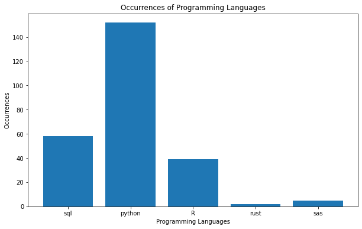

```python
import matplotlib.pyplot as plt

# Occurrence counts of programming languages
occurrences = {
    'sql': 58,
    'python': 152,
    'R': 39,
    'rust': 2,
    'sas': 5
}

# Extract languages and counts from the dictionary
languages = list(occurrences.keys())
counts = list(occurrences.values())

# Plotting the bar graph
plt.figure(figsize=(10, 6))
plt.bar(languages, counts)
plt.xlabel('Programming Languages')
plt.ylabel('Occurrences')
plt.title('Occurrences of Programming Languages')
plt.show()
```

Python appears to be the most popular programming language for discussion, followed by SQL and R.

##### Question 2

How has ChatGPT interest increased over time?

We check for ChatGPT mentions in thread titles, and plot them in a time series.

```python
# Filtering for thread titles containing

from pyspark.sql.functions import col, lower, regexp_extract, date_format

chatgpt_count = submissions_ds.withColumn('year_month', date_format(col('created_utc'), 'yyyy-MM'))
chatgpt_count = chatgpt_count.withColumn('year_month_day', date_format(col('created_utc'), 'yyyy-MM-dd'))
chatgpt_count = chatgpt_count.filter(regexp_extract(col('title'), r'(?i)\b(chatgpt)\b', 0) != "")

chatgpt_count.select('title', 'created_utc', 'year_month', 'year_month_day').show()
```

```
StatementMeta(068f5dc9-cad0-404f-b813-890e0a09f2cd, 13, 34, Finished, Available)
```

```
+--------------------+-------------------+----------+--------------+
|               title|        created_utc|year_month|year_month_day|
+--------------------+-------------------+----------+--------------+
|Tutorial on how t...|2023-03-29 17:28:26|   2023-03|    2023-03-29|
|I wrote up a guid...|2023-01-12 19:01:24|   2023-01|    2023-01-12|
|If Condon can be ...|2023-01-26 21:53:10|   2023-01|    2023-01-26|
|ChatGPT is talkin...|2023-01-24 19:41:59|   2023-01|    2023-01-24|
|Do you think Chat...|2023-01-24 20:24:09|   2023-01|    2023-01-24|
|DALL-E, ChatGPT, ...|2023-01-31 05:05:07|   2023-01|    2023-01-31|
|Impact of ChatGPT...|2023-01-25 16:40:32|   2023-01|    2023-01-25|
|Creating Real-Wor...|2023-01-28 21:40:26|   2023-01|    2023-01-28|
|ChatGPT documents...|2023-01-05 20:43:31|   2023-01|    2023-01-05|
|ChatGPT integrate...|2023-01-05 20:44:16|   2023-01|    2023-01-05|
|ChatGPT builds R ...|2023-01-05 20:44:46|   2023-01|    2023-01-05|
|ChatGPT generates...|2023-01-05 20:45:13|   2023-01|    2023-01-05|
|[OC] ChatGPT tran...|2023-01-05 20:45:51|   2023-01|    2023-01-05|
|100+ Best Chatgpt...|2023-02-07 16:37:28|   2023-02|    2023-02-07|
|I asked ChatGPT t...|2023-01-18 04:50:28|   2023-01|    2023-01-18|
|With the rise of ...|2023-02-14 17:37:03|   2023-02|    2023-02-14|
|Chatgpt taking ou...|2023-01-20 16:12:22|   2023-01|    2023-01-20|
|How to explain Ch...|2023-01-12 05:18:31|   2023-01|    2023-01-12|
|ChatGPT vs Bing f...|2023-02-13 18:00:07|   2023-02|    2023-02-13|
|Will ChatGPT stea...|2023-01-06 04:49:03|   2023-01|    2023-01-06|
+--------------------+-------------------+----------+--------------+
only showing top 20 rows
```

```python
# Grouping data by yyyy_mm_dd

from pyspark.sql.functions import avg, expr, percentile_approx, count

chatgpt_count2 = chatgpt_count.groupBy("year_month_day") \
    .agg(count("*").alias("title_count") \
    ) \

chatgpt_count2.orderBy(col('year_month_day').desc()).show()
chatgpt_count2 = chatgpt_count2.orderBy(col('year_month_day').desc()).toPandas()
```

```
StatementMeta(068f5dc9-cad0-404f-b813-890e0a09f2cd, 13, 35, Finished, Available)
```

```
+--------------+-----------+
|year_month_day|title_count|
+--------------+-----------+
|    2023-03-31|          1|
|    2023-03-30|          1|
|    2023-03-29|          1|
|    2023-03-27|          3|
|    2023-03-26|          1|
|    2023-03-25|          1|
|    2023-03-24|          2|
|    2023-03-23|          1|
|    2023-03-22|          2|
|    2023-03-21|          2|
|    2023-03-19|          2|
|    2023-03-16|          2|
|    2023-03-13|          1|
|    2023-03-11|          1|
|    2023-03-10|          1|
|    2023-03-08|          2|
|    2023-03-07|          2|
|    2023-03-06|          2|
|    2023-03-05|          1|
|    2023-03-03|          2|
+--------------+-----------+
only showing top 20 rows
```

```python
# Grouping data by yyyy_mm

from pyspark.sql.functions import avg, expr, percentile_approx, count

chatgpt_count3 = chatgpt_count.groupBy("year_month") \
    .agg(count("*").alias("title_count") \
    ) \

chatgpt_count3.orderBy(col('title_count').desc()).show()
```

```
StatementMeta(068f5dc9-cad0-404f-b813-890e0a09f2cd, 13, 36, Finished, Available)
```

```
+----------+-----------+
|year_month|title_count|
+----------+-----------+
|   2023-03|         36|
|   2023-01|         26|
|   2023-02|         21|
+----------+-----------+
```

```
StatementMeta(068f5dc9-cad0-404f-b813-890e0a09f2cd, 13, 37, Finished, Available)
```

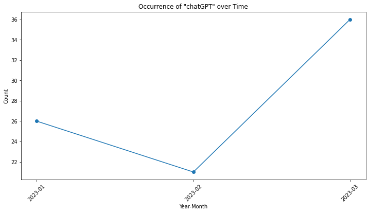

```python
import matplotlib.pyplot as plt
from pyspark.sql.functions import count

# Calculate the count of occurrences for each year-month
monthly_counts = chatgpt_count.groupBy('year_month').agg(count('*').alias('count')).orderBy('year_month')

# Extract the year-month and count values from the DataFrame
x_values = [row['year_month'] for row in monthly_counts.collect()]
y_values = [row['count'] for row in monthly_counts.collect()]

# Plotting the data
plt.figure(figsize=(12, 6))
plt.plot(x_values, y_values, marker='o')
plt.xlabel('Year-Month')
plt.ylabel('Count')
plt.title('Occurrence of "chatGPT" over Time')
plt.xticks(rotation=45)
plt.show()
```

Some months have unequal number of days. Instead of looking at raw numbers of thread titles, "mentions_per_day" is created to see if any difference is made. Ultimately the trend appears to be the same.

```python
# Creation of "mentions_per_day" variable

from pyspark.sql.functions import avg, expr, percentile_approx, count, round

chatgpt_count1 = chatgpt_count.groupBy("year_month") \
    .agg(count("*").alias("title_count"), \
        expr("day(last_day(to_date(year_month, 'yyyy-MM'))) as max_days_in_month") \
    ) \

chatgpt_count1 = chatgpt_count1.withColumn("mentions_per_day", round(col("title_count") / col("max_days_in_month"), 2))


chatgpt_count1.orderBy(col('year_month').desc()).show()
chatgpt_count1 = chatgpt_count1.orderBy(col('year_month').desc()).toPandas()
```

```
StatementMeta(068f5dc9-cad0-404f-b813-890e0a09f2cd, 13, 38, Finished, Available)
```

```
+----------+-----------+-----------------+----------------+
|year_month|title_count|max_days_in_month|mentions_per_day|
+----------+-----------+-----------------+----------------+
|   2023-03|         36|               31|            1.16|
|   2023-02|         21|               28|            0.75|
|   2023-01|         26|               31|            0.84|
+----------+-----------+-----------------+----------------+
```

```
StatementMeta(068f5dc9-cad0-404f-b813-890e0a09f2cd, 13, 39, Finished, Available)
```

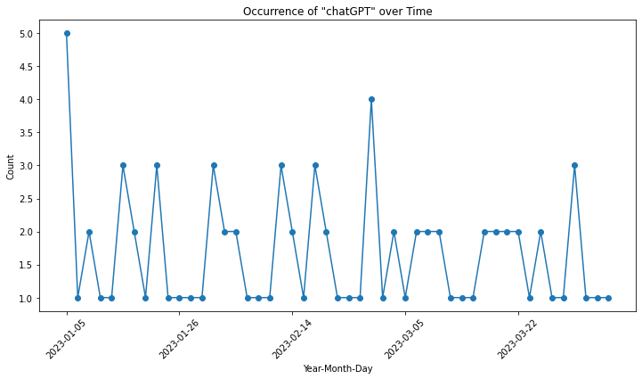

```python
import matplotlib.pyplot as plt
from pyspark.sql.functions import count

# Calculate the count of occurrences for each year-month-day
daily_counts = chatgpt_count.groupBy('year_month_day').agg(count('*').alias('count')).orderBy('year_month_day')

# Extract the year-month-day and count values from the DataFrame
x_values = [row['year_month_day'] for row in daily_counts.collect()]
y_values = [row['count'] for row in daily_counts.collect()]

# Plotting the data
plt.figure(figsize=(12, 6))
plt.plot(x_values, y_values, marker='o')
plt.xlabel('Year-Month-Day')
plt.ylabel('Count')
plt.title('Occurrence of "chatGPT" over Time')

# Customize x-axis tick labels to display only every 10th date
x_ticks = plt.gca().get_xticks()
plt.gca().set_xticks(x_ticks[::10])

plt.xticks(rotation=45)
plt.show()
```

##### Question 3

Who are the top contributors of the subreddit?

We filter out deleted users, and aggregate counts of thread and comment postings by user name.

```python
from pyspark.sql.functions import count

submissions_count = (
    submissions_ds.filter(~submissions_ds.author.contains("[deleted]"))
        .groupBy(submissions_ds.author)
        .agg(count("*").alias("submissions_count"))
)
```

```
StatementMeta(068f5dc9-cad0-404f-b813-890e0a09f2cd, 13, 40, Finished, Available)
```

```python
comments_count = (
    comments_ds.filter(~comments_ds.author.contains("[deleted]"))
        .groupBy(comments_ds.author)
        .agg(count("*").alias("comments_count"))
)
```

```
StatementMeta(068f5dc9-cad0-404f-b813-890e0a09f2cd, 13, 41, Finished, Available)
```

```python
analytics1 = submissions_count.join(comments_count, submissions_count.author == comments_count.author, "left") \
    .select(submissions_count.author, submissions_count.submissions_count, comments_count.comments_count) \
    .withColumn("submissions_comment_ratio", round((submissions_count.submissions_count/comments_count.comments_count), 2)) \
    .withColumn("comment_submissions_ratio", round((comments_count.comments_count/submissions_count.submissions_count), 2))

analytics1.count()
```

```
StatementMeta(068f5dc9-cad0-404f-b813-890e0a09f2cd, 13, 42, Finished, Available)
```

```
3157
```

```python
analytics1.orderBy(analytics1.submissions_comment_ratio.desc()).show(10)
```

```
StatementMeta(068f5dc9-cad0-404f-b813-890e0a09f2cd, 13, 43, Finished, Available)
```

```
+--------------------+-----------------+--------------+-------------------------+-------------------------+
|              author|submissions_count|comments_count|submissions_comment_ratio|comment_submissions_ratio|
+--------------------+-----------------+--------------+-------------------------+-------------------------+
|            limedove|                8|             1|                      8.0|                     0.13|
|Beginning-Scholar105|                6|             1|                      6.0|                     0.17|
|      SnooHabits4550|                5|             1|                      5.0|                      0.2|
|               crn4t|                4|             1|                      4.0|                     0.25|
|       JimmySuicidex|                3|             1|                      3.0|                     0.33|
|              usc-ur|                3|             1|                      3.0|                     0.33|
|      Mighty__hammer|                3|             1|                      3.0|                     0.33|
|     mr_anonymous_26|                3|             1|                      3.0|                     0.33|
|   the_whisperer_guy|                3|             1|                      3.0|                     0.33|
|            cmauck10|                3|             1|                      3.0|                     0.33|
+--------------------+-----------------+--------------+-------------------------+-------------------------+
only showing top 10 rows
```

```python
analytics1.orderBy(analytics1.comment_submissions_ratio.desc()).show(10)
```

```
StatementMeta(068f5dc9-cad0-404f-b813-890e0a09f2cd, 13, 44, Finished, Available)
```

```
+--------------------+-----------------+--------------+-------------------------+-------------------------+
|              author|submissions_count|comments_count|submissions_comment_ratio|comment_submissions_ratio|
+--------------------+-----------------+--------------+-------------------------+-------------------------+
|   therealtiddlydump|                1|           546|                      0.0|                    546.0|
|    __god_bless_you_|                1|           178|                     0.01|                    178.0|
|         synthphreak|                1|           139|                     0.01|                    139.0|
|       Sorry-Owl4127|                1|           138|                     0.01|                    138.0|
|save_the_panda_bears|                1|           129|                     0.01|                    129.0|
|Character-Education3|                1|           127|                     0.01|                    127.0|
|  purplebrown_updown|                1|           116|                     0.01|                    116.0|
|       renok_archnmy|                4|           442|                     0.01|                    110.5|
|     blacksnowboader|                1|           108|                     0.01|                    108.0|
|            wil_dogg|                1|           108|                     0.01|                    108.0|
+--------------------+-----------------+--------------+-------------------------+-------------------------+
only showing top 10 rows
```

#### Additional Question

Here we attempted to include data from an external source, Microsoft stock data with the goal of comparing it to the dates in which ChatGPT was mentioned on the subreddit. We unfortunately could not get it to work in time.

```python
msft_prices_path = "https://ml.azure.com/fileexplorerAzNB?wsid=/subscriptions/0f349422-b42c-47b4-bc1c-8580f16bbf14/resourcegroups/project-group-3/providers/Microsoft.MachineLearningServices/workspaces/project-aml&tid=d689239e-c492-40c6-b391-2c5951d31d14&activeFilePath=Users/brendenmoore/big-data-project-team-sparked/code/starter-workbook.ipynb"
```

```
StatementMeta(068f5dc9-cad0-404f-b813-890e0a09f2cd, 13, 45, Finished, Available)
```

```python
# Read the Microsoft closing prices CSV into a DataFrame
msft_prices = spark.read.csv(msft_prices_path, header=True, inferSchema=True)

# Perform necessary transformations on the "msft_prices" DataFrame to match the date format
msft_prices = msft_prices.withColumn("Date", to_date(col("Date"), "MM/dd/yyyy"))

# Join the two DataFrames based on the "year_month_day" and "Date" columns
joined_data = chatgpt_count2.join(msft_prices, chatgpt_count2["year_month_day"] == msft_prices["Date"], "left")

# Show the joined data
joined_data.show()
```

```
StatementMeta(068f5dc9-cad0-404f-b813-890e0a09f2cd, 13, 46, Finished, Available)
```

[output not shown]

## Saving intermediate data

You should save your intermediate datasets as parquet to `azureml://datastores/workspaceblobstore/paths/<location>`.